# Отчет по лабораторной работе №6

Установка и настройка системы управления базами данных MariaDB

Виноградова М.А

Российский университет дружбы народов, Москва, Россия

8 октября 2026

# Информация

## Докладчик

- Виноградова Мария Андреевна
- студентка НПИбд-02-24
- номер студ. билета 1132240691
- Российский университет дружбы народов
- 1132240691@rudn.ru
- https://github.com/mavinogradova/study_2026-2027

# Цель работы

Приобретение практических навыков по установке и конфигурированию системы управления базами данных на примере программного обеспечения MariaDB.

# Задание

1. Установите необходимые для работы MariaDB пакеты (см. раздел 6.4.1).
2. Настройте в качестве кодировки символов по умолчанию utf8 в базах данных.
3. В базе данных MariaDB создайте тестовую базу addressbook, содержащую таблицу city с полями name и city, т.е., например, для некоторого сотрудника указан город, в котором он работает (см. раздел 6.4.1).
4. Создайте резервную копию базы данных addressbook и восстановите из неё данные (см. раздел 6.4.1).
5. Напишите скрипт для Vagrant, фиксирующий действия по установке и настройке базы данных MariaDB во внутреннем окружении виртуальной машины server. Соответствующим образом следует внести изменения в Vagrantfile (см. раздел 6.4.5).

# Выполнение лабораторной работы

## Установка MariaDB. Установка пакетов

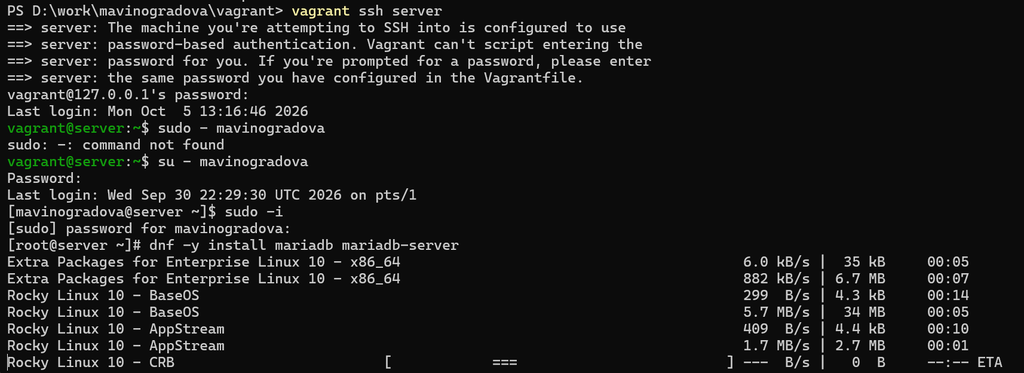

Вход на виртуальную машину server под пользователем mavinogradova, переход в режим суперпользователя и установка пакетов mariadb и mariadb-server

## Установка MariaDB. Просмотр конфигурационных файлов

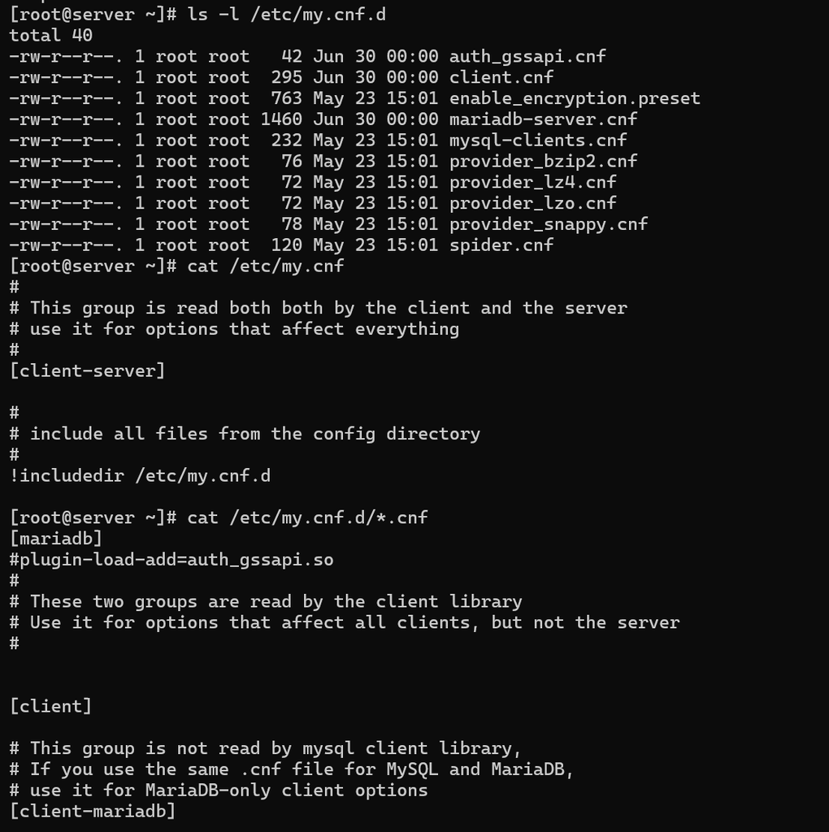

Просмотр конфигурационных файлов MariaDB

## Установка MariaDB. Запуск и включение службы

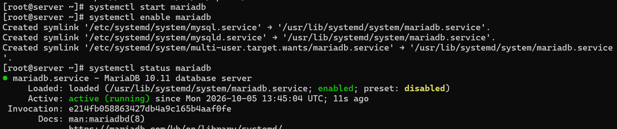

Запуск и включение службы mariadb, проверка её статуса

## Установка MariaDB. Проверка прослушиваемого порта

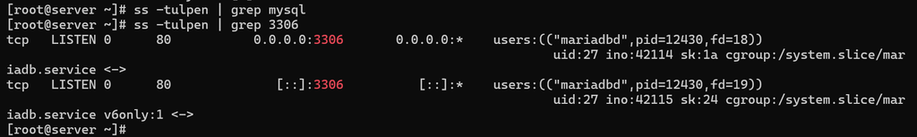

Проверка прослушиваемого порта

## Установка MariaDB. Настройка безопасности

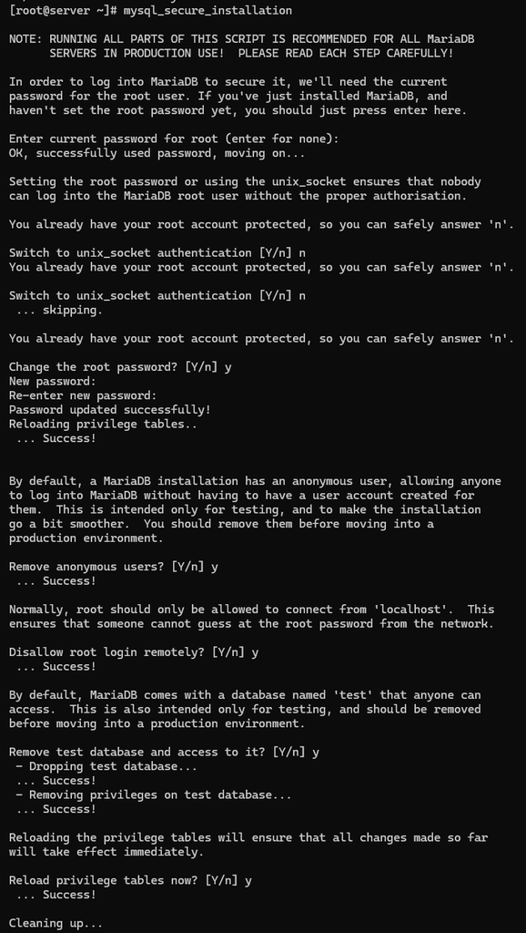

Запуск mysql_secure_installation

## Установка MariaDB. Вход в базу данных

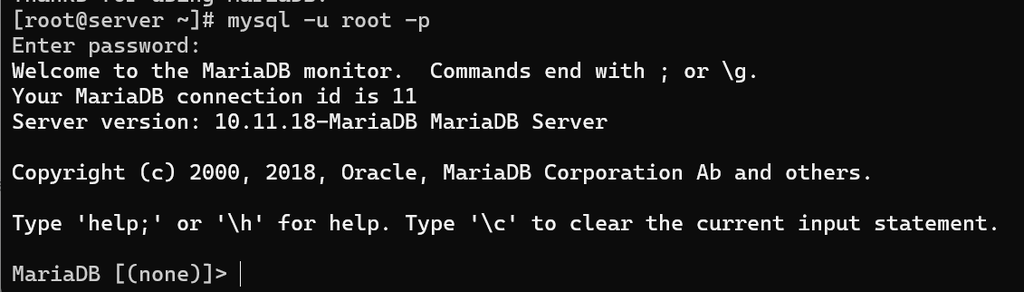

Вход в базу данных с правами администратора

## Установка MariaDB. Список команд клиента

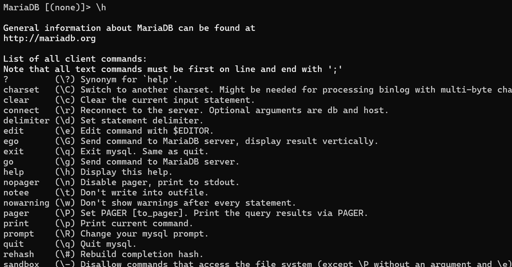

Список команд клиента MariaDB

## Установка MariaDB. Список доступных баз данных

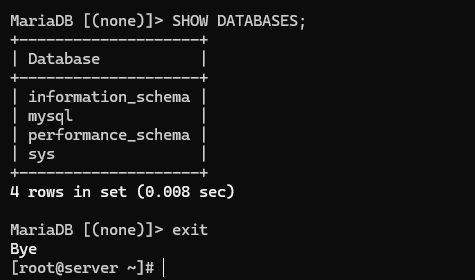

Вывод списка доступных баз данных MariaDB

## Конфигурация кодировки. Статус до изменения

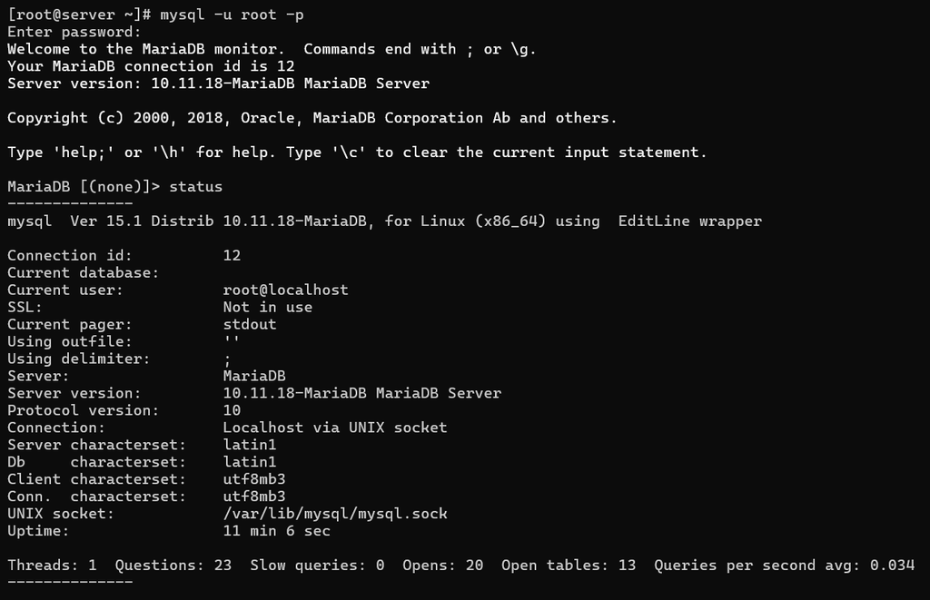

Вывод статуса MariaDB до изменения кодировки

## Конфигурация кодировки. Создание файла utf8.cnf

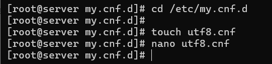

Создание файла конфигурации utf8.cnf

## Конфигурация кодировки. Содержимое utf8.cnf

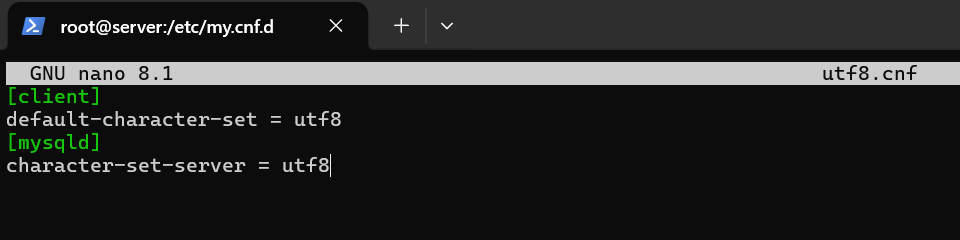

Содержимое файла utf8.cnf

## Конфигурация кодировки. Перезапуск службы

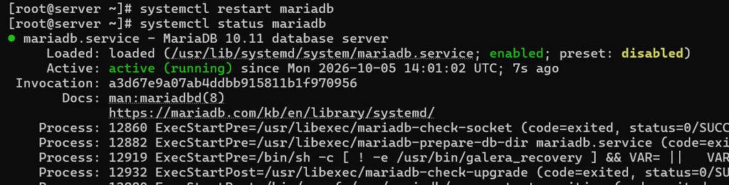

Перезапуск службы mariadb

## Конфигурация кодировки. Статус после изменения

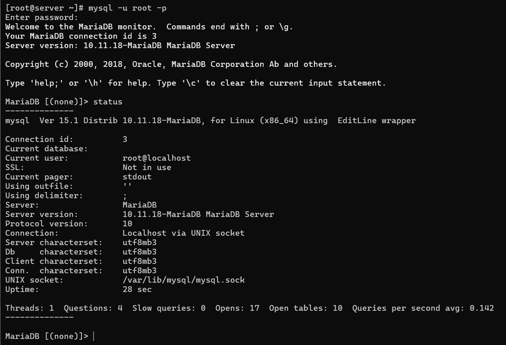

Вывод статуса MariaDB после изменения кодировки

## Создание базы данных. Создание addressbook

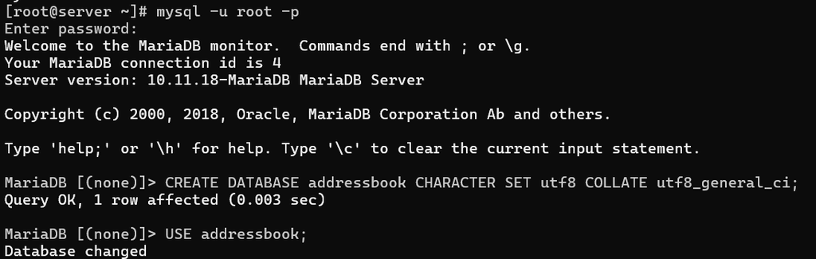

Создание базы данных addressbook

## Создание базы данных. Таблица city

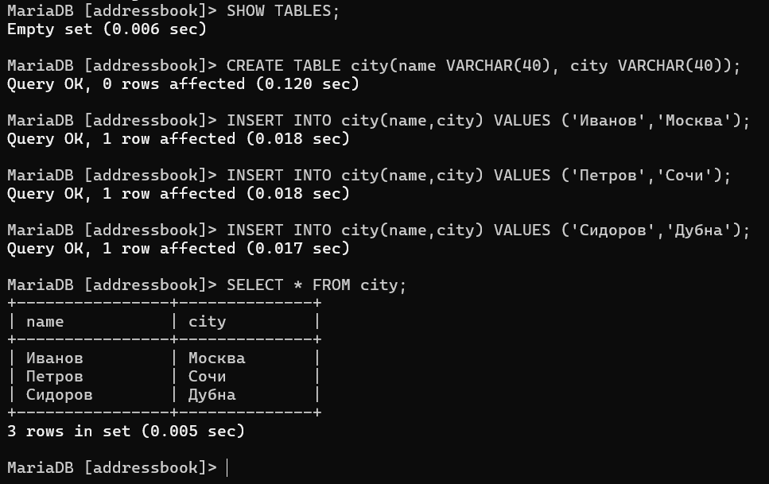

Создание таблицы city и заполнение её данными

## Создание базы данных. Пользователь и права

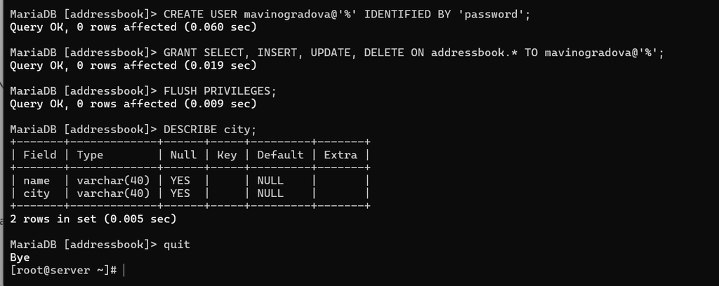

Создание пользователя и выдача прав

## Создание базы данных. Проверка через mysqlshow

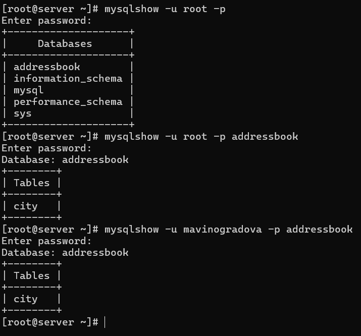

Просмотр списка баз данных и таблиц

## Резервные копии. Обычная копия

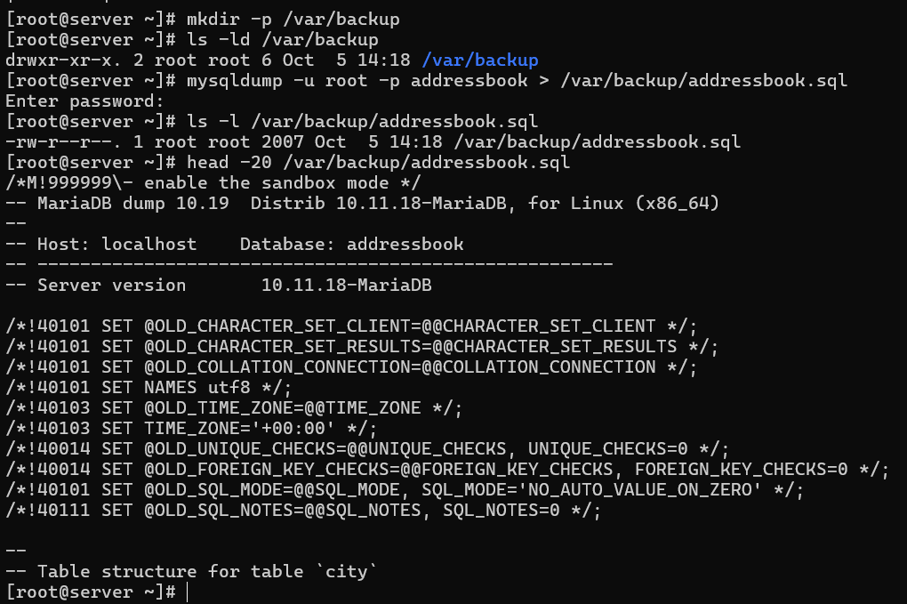

Создание каталога /var/backup и обычной резервной копии

## Резервные копии. Сжатые копии

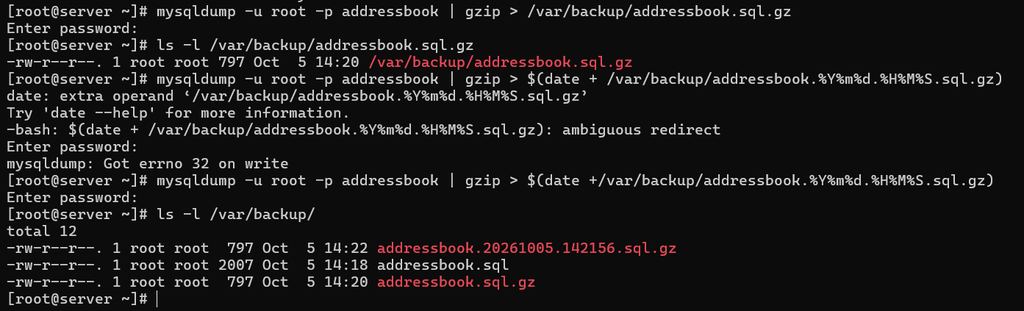

Создание сжатых резервных копий

## Резервные копии. Восстановление из .sql

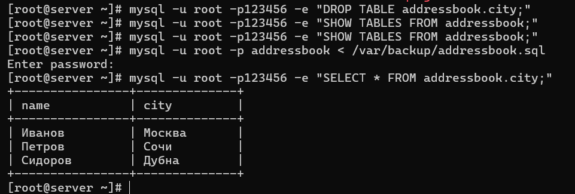

Восстановление базы данных из несжатой резервной копии

## Резервные копии. Восстановление из .gz

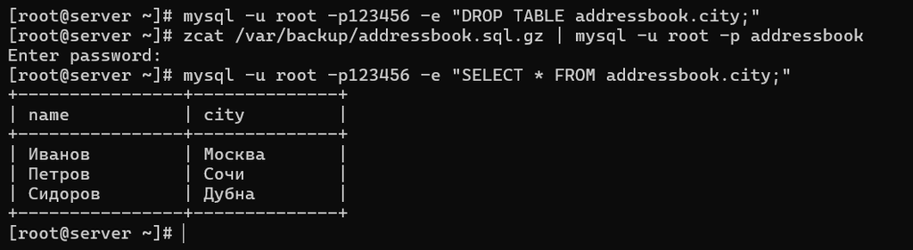

Восстановление базы данных из сжатой резервной копии

## Внесение изменений в окружение. Копирование файлов

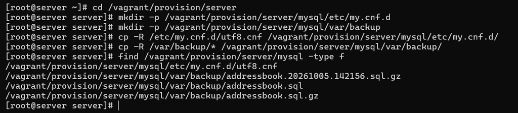

Копирование конфигурационного файла и резервных копий в каталог провижининга

## Внесение изменений в окружение. Создание mysql.sh

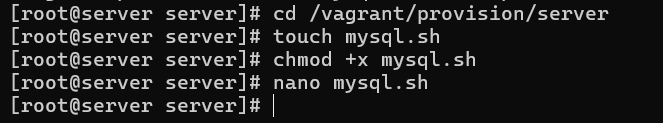

Создание исполняемого файла mysql.sh

## Внесение изменений в окружение. Содержимое mysql.sh

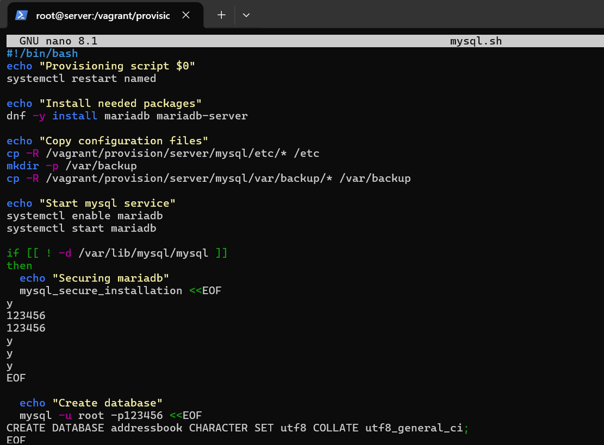

Содержимое скрипта провижининга mysql.sh

## Внесение изменений в окружение. Правка Vagrantfile

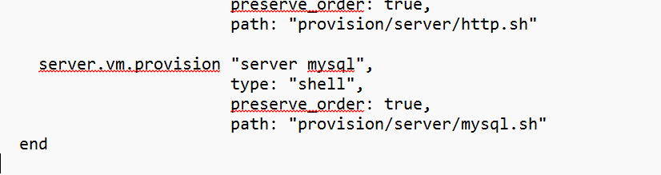

Фрагмент Vagrantfile с добавленным блоком провижининга

# Выводы

В ходе лабораторной работы были приобретены практические навыки по установке и конфигурированию СУБД MariaDB. Установлены пакеты `mariadb` и `mariadb-server`, служба включена в автозапуск и запущена. Настроена кодировка символов по умолчанию utf8 через файл `utf8.cnf`. Создана тестовая база данных `addressbook` с таблицей `city` и тремя записями, создан пользователь с правами `SELECT`, `INSERT`, `UPDATE`, `DELETE` на эту базу. Освоены резервное копирование (несжатое, сжатое, с датой в имени) и восстановление базы данных. Написан скрипт провижининга `mysql.sh`, автоматизирующий установку и настройку MariaDB, и внесены соответствующие изменения в `Vagrantfile`.